YQL /date{0205}

# 双重机器学习与stata应用

双重机器学习可对单次机器学习可能存在的正则化偏差进行纠偏  
ddml（pystacked）包支持的主回归模型有：

- 部分线性模型（partially linear model）
- 交互模型（interactive model）（仅适用于核心解释变量为01变量(一般做did用)）
- 部分线性工具变量模型（partially linear IV model）

...  
只需要知道第一个如何实现，其余的类似

*注：陈强老师提到标准did可以用dml，交错did就用交错做主回归，只在稳健性用dml无功无过*  
***dml无法解决内生性问题**，只是得益于machine learning能够尽可能得到较为纯净的估计效应*

## 部分线性模型（partially linear model）

$ Y= D\theta_0+g_o(X)+U$ , $E[U|X,D]=0$

$Y$为结果变量，$D$为处理变量（可以是连续型），$\theta_0$为感兴趣的参数（也就是我们因果推断关注的回归系数），$X$为控制变量，$g_0(\cdot)$为未知非参函数（连函数形式都为未知），$U$为误差项。

为避免函数形式误设，使用半参数回归来估计$E(Y|X)$与$E(D|X)$；因此，本质上DML与传统线性回归的差别在于，其允许控制变量以非线性方式影响Y和D，并使用机器学习方法更好的拟合这些非线性关系，在高维设定下更稳健（因此支持加入非常多的控制变量）

crossfitting的思想是使用一半样本进行一阶段dml估计，另一半进行二阶段估计，以此解决相关性问题。当然更常用的方法是k折交叉拟合（K-fold cross-fitting)，简单来说，k折5次即将样本分为5份，4份用于训练1份用于检验，即样本分割比例1：4。

#### 在DML框架下估计部分线性模型的步骤如下：

- 将样本随机分为k份
- 对每一份样本：使用k-1份样本拟合E[D|X]和E[Y|X]
- 计算残差：（剥离X对D和Y的影响，以在第二阶段估计D对Y净因果效应）

$\widetilde{y}=Y-E[Y|X]$  
$\widetilde{d}=D-E[D|X]$

- 用残差估计参数：${\theta_0}:{\widehat{\theta}}={(\widetilde{d}'\widetilde{d})^{-1}}{\widetilde{d}'\widetilde{y}}$

## stata操作示例

### 1、ddml估计

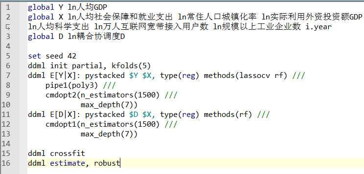

代码简述：

- 1-3行：分别设定Y，X，D变量
- 5：设置随机种子（随便填数字即可，理论上随机种子可调参但对于不同模型结果不稳健）
- 6：设置主回归模型及样本分割比例：“init partial”即设定部分线性模型，“kfolds（5）”即样本按1：4分割
- 7-10：此步骤即拟合E[Y|X]。其中，**methods（...）** 括号内为选择的机器学习方法（也支持选用ols），如上图所示可选择多个模型（堆叠回归）

**pipe1(poly3)** 意为：使用第一个模型时，为**控制变量** 集合添加三次项变换（我认为三次项变换只针对模型本身为线性的时候使用即可，如lasso和神经网络nnet，但有发刊论文在使用随机森林rf时也添加了此变换，可能问题不大）；**cmdopt2（...）** 即针对第二个模型进行调参，后面的1500和7分别为树的量和最深的参数，下同

- 11-13即拟合E[D|X]，其中的命令和参数同含义
- 15-16即自动将一阶段的预测结果计算残差（计算Dresid和Yresid）并纳入二阶段回归中，并生成稳健的估计结果。

*注：help文件中，作者给了手搓estimate的示例，运行结果与直接运行ddml estimate的结果几乎相同，分解式的代码方便理解原理*

## 稳健性检验汇总（仅汇总与dml方法相关的稳健性）

- 改变样本分割比例（即更改kfolds的参数，常用为3、5、8、10）
- 使用其他机器学习方法
- 重设主回归模型（将部分线性改为交互，适合did）
- 逐步纳入控制变量集合的多次项
- 绘制变量拟合图，展示所选模型能够较好捕捉非线性特征，避免选择偏误（见：欧阳志刚,李伟.货币政策和小微企业“融资难”——基于央行担保品渠道的实证[J].江西师范大学学报(哲学社会科学版),2024,57(05):64-79.）